# Chapter 11: Classes

Author

Khiem Nguyen – khiem.nguyen@glasgow.ac.uk

# 1 Member access

We have used structs in all the example in the last Chapter.

We study now **access level** to debunk the meaning of two keywords `private` and `public`.

## 1.1 Member access

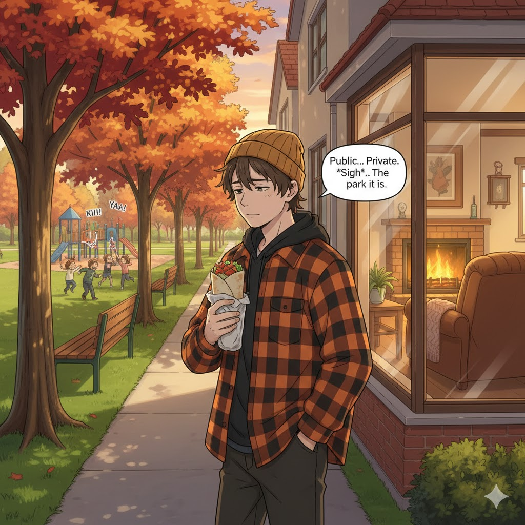

You feel tired on the way going home and want to sit down in peace as you are an introvert. Two choices:

- The park with all the screaming kids. Not want to hear all the screamings. It is `public`, you can access.
- The private residential house with warm and TV. Want to sit in silence. It is `private`, you cannot access.

*It is not about what you want, but about what you can.*

## 1.2 Member access

✎ Each member of a class type (`struct` or `class`) have a property called an **access level**.

✎ **Access level** determines who can access that member:

1. `public`
2. `private`
3. `protected`

We’ll cover

- `public` and `private` in this Chapter
- `protected` in Chapter “Inheritance”.

## 1.3 Members of a struct are public by default

**Terminologies**

- Members that have the public access level are called **public members**.
- **Public members** are members of a class type that do not have any restrictions on how they can be accessed.

**Meaning**

- Public members can be accessed by other members of the same class.
- **Public members can also be accessed by the public**, which is what we call code that exists outside the members of a given class type.

**Key points to remember**

- The members of a struct are public by default.
- Public members can be accessed by other members of the class type, and by public

## 1.4 Members of a struct are public by default: Example

We have done this all the time before:

Listing 1: All the members of a struct are `public` by default. Filename=`struct_public_by_default.cpp`

```cpp
#include <iostream>

struct Date
{
    // struct members are public by default, can be accessed by anyone
    int year {};       // public by default
    int month {};      // public by default
    int day {};        // public by default

    void print() const // public by default
    {
        // public members can be accessed in member functions of the class type
        std::cout << year << '/' << month << '/' << day;
    }
};

// non-member function main is part of "the public"
int main()  // main is not a member of Date, it is part of `public`.
{
    Date today { 2020, 10, 14 }; // aggregate initialize our struct

    // public members can be accessed by the public
    today.day = 42;     // okay: the day member is public. That's why it's dangerous
    today.month = 42;   // okay: the month member is public. That's why it's dangerous
    today.year = -42;   // okay: the year member is public. That's why it's dangerous
    today.print();      // okay: the print() member function is public

    return 0;
}
```

## 1.5 The members of a class are private by default

Now, look at this example again but using `class` instead of `struct`:

Listing 2: All the members of a class are `private` by default. Filename=`class_private_by_default.cpp`

```cpp
#include <iostream>

class Date // now a class instead of a struct
{
    // class members are private by default, can only be accessed by other members
    int year {};     // private by default
    int month {};    // private by default
    int day {};      // private by default

    void print() const // private by default
    {
        // private members can be accessed in member functions
        std::cout << year << '/' << month << '/' << day;
    }
};

int main()  // main is a part of public
{
    // Date today { 2020, 10, 14 }; // compile error: can no longer use aggregate initialization

    // private members can not be accessed by the public
    // You cannot do something silly like this.
    /*
    today.m_day = 42;   // compile error: the m_day member is private.
    today.m_month = 42; // compile error: the m_month member is private.
    today.m_year = 42;  // compile error: the m_year member is private.
    today.print();      // compile error: the print() member function is private.
    */
    return 0;
}
```

## 1.6 The members of a class are private by default

**Key points to remember**

- The members of a class are private by default.
- Private members can be accessed by other members of the class type, **but cannot be accessed by public**

**Repeat**

`struct` and `class` are only different by technical detail, but essentially interchangeable:

- To make `struct` look like `class`, we make all the members `private`.
- To make `class` look like `struct`, we make all the members `public`.

## 1.7 Naming your private member variables

✎ It is a common convention to *name private data members starting with an* `m_` *prefix.* But $\ldots$ talk later.

Consider:

```cpp
// Some member function that sets private member m_name to
// the value of the name parameter
void set_name(std::string_view name)
{
    m_name = name;
}
```

- The `m_` prefix differentiates data members from function parameters or local variables.
- The `m_` prefix helps prevent naming collisions between private member variables and the names of local variables.

## 1.8 Naming your private member variables

➥ If we had named private members `name` instead of `m_name`, it looks like this

```cpp
// then we need to change the parameter's name here
void set_name(std::string_view name)
{
    // function parameter "name" shadows the private data member "name"
    name = name // of course won't work
}
```

➥ But $\ldots$ soon we will see this is even not necessary in modern C++.

**Well, why do I need to mention?**

- You need to read legacy code when you go to industry.
- But the use of prefix `m_` is declining.
- Many high-profile open-source projects have moved away from `m_` in **favor of a trailing underscore** (`variable_`) or **no prefix at all**

## 1.9 Naming your private member variables: Examples

**Examples** – Click on the links to show the students examples

- **Google**: trailing underscore `variable_`
- **PyTorch** (famous Machine Learning framework): no prefix, no suffix

  [**Link to one example**](https://github.com/pytorch/pytorch/blob/main/torch/csrc/api/include/torch/nn/modules/linear.h), Lines 68 – 75
- **deal.II** (famous finite element library): no prefix, no suffix

  [**Link to one example**](https://github.com/dealii/dealii/blob/master/include/deal.II/fe/fe.h), Lines 2522 – 2721

**Morale of the story**

- All the examples in real-world libraries/application look extremely complicated.
- But $\ldots$ *Hey! You want to earn $6$-digit salary and want it to look simple?*

**I am not against GenAI chatbot.** You can hate me now but I want to say this:

You want to get the job in industry after using ChatGPT/Gemini to generate solution for the programming courses?

**Just think about that!?!?** 😏😏😏

## 1.10 Setting access levels via access specifiers

✎ We can explicitly set the access level of our members by using an access specifier.

✎ An access specifier sets the access level of all members that follow the specifier.

✎ Three access specifiers:

- `public:`
- `private:`
- `protected:`

## 1.11 Setting access levels via access specifiers: Example

Listing 3: We can use access specifiers to define access levels of members. Filename=`access_specifier_example.cpp`

```cpp
#include <iostream>
class Date
{
// Any members defined here would default to private

public: // here's our public access specifier

    void print() const // public due to above public: specifier
    {
        // members can access other private members
        std::cout << year << '/' << month << '/' << day;
    }

private: // here's our private access specifier

    int year { 2020 };  // private due to above private: specifier
    int month { 14 }; // private due to above private: specifier
    int day { 10 };   // private due to above private: specifier
};

int main()
{
    Date d{};
    d.print();  // okay, main() allowed to access public members

    return 0;
}
```

✎ We can omit `private:` specifier in `class` as classes default to `private` access.

➥ Let us compile and run this code.

## 1.12 Access level summary

| Access level | Access specifier | Member access | Derived class access | Public access |
| --- | --- | --- | --- | --- |
| Public | `public:` | yes | yes | yes |
| Protected | `protected:` | yes | yes | no |
| Private | `private:` | yes | no | no |

**Don’t worry! We talk about this later.**

- Some little practice will get you understand and remember them.
- However, notice the triangle pattern of “yes” and triangle pattern of “no”.

## 1.13 Access levels work on a per-class basis

✎ One nuance of C++ access levels that is often missed or misunderstood is that – otherwise, it is a real big headache:

**Access to members is defined on a per-class basis, not on a per-object basis.**

## 1.14 Access levels work on a per-class basis: Example

Listing 4: Access levels work on per-class basis, not on object basis. Filename=`access_level_per_class_basis.cpp`

```cpp
#include <iostream>
#include <string>
#include <string_view>

class Person
{
private:
    std::string name{};

public:
    void kisses(const Person& p) const
    {   // we access data member "name" of object "p"
        std::cout << name << " kisses " << p.name << '\n';
    }

    void set_name(std::string_view name)
    {   // this is the pointer to the "current" object.
        // This is why we don't need to use m_name, or name_
        // and everything still appears normal and sensible.
        this->name = name;
    }
};

int main()
{
    Person joe;
    joe.set_name("Joe");
    Person kate;
    kate.set_name("Kate");
    joe.kisses(kate);

    return 0;
}
```

➥ We can access member `name` of the object `p` in the member function `kisses`.

➥ `p.name` is not private to only `p`. Any member functions of `Person` can access `name` of other `Person` objects.

# 2 A detour back to pointers & class type (`struct` and `class`)

You have just seen `this->name`.

- But we skip the lecture on `struct` on purpose.
- I explained why we skip the lecture on `struct`.
- Now, I have to pay the price. We must make a detour to revisit pointers.

## 2.1 What is an aggregate?

- In general programming, an aggregate data type (also called an aggregate) is any type that can contain multiple data members.
- Some types of aggregates allow members to have different types (e.g. structs).
- Others require that all members must be of a single type (e.g. arrays).

**In our course:**

When we use the term “aggregate” (or “non-aggregate”) we will mean the C++ definition of aggregate.

## 2.2 Aggregate initialization of a struct: Example

Listing 5: We can initialize aggregate by using copy-list initialization or list initialization. Filename=`aggregate_initialization.cpp`

```cpp
#include <iostream>
struct Employee
{
    int id {};          // default initialization
    int age {42};       // default initialization
    double wage {};     // default initialization
};

int main()
{
    // copy-list initialization using braced list
    Employee frank = { 1, 32, 60000.0 };
    // list initialization using braced list (preferred)
    Employee joe { 2, 28, 45000.0 };
    // id, age and wage will be initialized by default as above
    Employee khiem {};
    std::cout << "khiem.age = " << khiem.age << "\nkhiem.wage = " << khiem.wage << '\n';
    return 0;
}
```

**Best practice**: Prefer the (non-copy) braced list form when initializing aggregates.